# STARS_SSN_V6

Luke Vawter

8/2/2022

# 1 -Introduction-

This a version of the SSN script is based very closely off the SSNvignette2014.pdf:

SSN: An R Package for Spatial Statistical Modelingon Stream Networks

Jay M. Ver Hoef, NOAA, Alaska Fisheries Science Center

Erin E. Peterson, CSIRO, Division of Mathematics, Informatics and Statistics

David Clifford, CSIRO, Division of Mathematics, Informatics and Statistics

Rohan Shah, CSIRO, Division of Mathematics, Informatics and Statistics

# 2 Install Packages and Set Data Path and Working Directory

import SSN package

```r
library("SSN")
```

set working directory for the ssn note: the lsn.ssn files are the same as those used in our previous model: STARS_SSN_V5

```r
# file.copy(system.file("data/ICPRB6", package = "SSN"),
# to = tempdir(), recursive = TRUE, copy.mode = FALSE)
# ## [1] TRUE
# setwd(tempdir())

path = "data/ICPRB6/lsn.ssn"
```

Set path to data directory. # 3. The S4 SpatialStreamNetwork object

In the Vignettethe structure of the data input into a SpatialStreamNetwork object is described in detail. I will not be recounting it here, but I recommend reading through it if you want a clearer understanding of the data that is being processed, or the required structure of any data set you might wish to input into this model.

# 4.2. Importing and subsetting the SpatialStreamNetwork object

Import the data into an SSN object.

```r
ssn_main <- importSSN(path,
predpts = "preds")
```

```
## binaryID.db already exists - no changes were made to binaryID.db table
```

# 4.3. Generating an additive function value

needs attention -our data is not in the same place

```r
####our data is not in the same place
# head(ssn_main@point@data)##[, c("GAGE","LONG_")])

# head(mf04p@data[, c("h2oAreaKm2",
# "afvArea", "computed.afv")])

# ssn_main_test <- additive.function(ssn_main, AREAKM2, test_cov)
```

# 4.4. Calculating distance matrices

Create distance matrix and access, assigning to distPred “Using the getStreamDistMat function allows accessing the asymmetric stream distance matrix after it is created.”

```r
createDistMat(ssn_main, predpts = "preds", o.write = TRUE,
amongpreds = TRUE)

distPred <- getStreamDistMat(ssn_main, Name = "preds")
str(distPred)
```

```
## List of 6
##  $ dist.net1.a: num [1:1475, 1:23130] 0 0 0 0 0 0 0 0 0 0 ...
##   ..- attr(*, "dimnames")=List of 2
##   .. ..$ : chr [1:1475] "1" "2" "3" "4" ...
##   .. ..$ : chr [1:23130] "2799" "2800" "2801" "2802" ...
##  $ dist.net1.b: num [1:23130, 1:1475] 18918 18918 18918 18918 18918 ...
##   ..- attr(*, "dimnames")=List of 2
##   .. ..$ : chr [1:23130] "2799" "2800" "2801" "2802" ...
##   .. ..$ : chr [1:1475] "1" "2" "3" "4" ...
##  $ dist.net1  : num [1:23130, 1:23130] 0 0 0 0 0 0 0 0 0 0 ...
##   ..- attr(*, "dimnames")=List of 2
##   .. ..$ : chr [1:23130] "2799" "2800" "2801" "2802" ...
##   .. ..$ : chr [1:23130] "2799" "2800" "2801" "2802" ...
##  $ dist.net2.a: num [1:1323, 1:20046] 3650 3650 3650 3650 3650 ...
##   ..- attr(*, "dimnames")=List of 2
##   .. ..$ : chr [1:1323] "28" "29" "30" "31" ...
##   .. ..$ : chr [1:20046] "7859" "7860" "7861" "7862" ...
##  $ dist.net2.b: num [1:20046, 1:1323] 0 0 0 0 0 0 0 0 0 0 ...
##   ..- attr(*, "dimnames")=List of 2
##   .. ..$ : chr [1:20046] "7859" "7860" "7861" "7862" ...
##   .. ..$ : chr [1:1323] "28" "29" "30" "31" ...
##  $ dist.net2  : num [1:20046, 1:20046] 0 0 0 0 0 0 0 0 0 0 ...
##   ..- attr(*, "dimnames")=List of 2
##   .. ..$ : chr [1:20046] "7859" "7860" "7861" "7862" ...
##   .. ..$ : chr [1:20046] "7859" "7860" "7861" "7862" ...
```

# 5. Data analysis using SSN

# 5.1. Exploratory data analysis

output the names of the elements of the data

```r
names(ssn_main)
```

```
## $Obs
##  [1] "SITEID"     "LONG_"      "LAT"        "DATE_"      "YEAR_"
##  [6] "MONTH_"     "GNIS_NAME"  "HUC12"      "GAGE"       "WEATHER"
## [11] "COMID"      "TWAT"       "TAIR"       "PRECIP"     "SOLRAD"
## [16] "ELEV"       "SLOPE"      "PURB16"     "PFOR16"     "PAG16"
## [21] "PWSTOR16"   "PCAN14"     "PIMP14"     "PEWET"      "PFWET"
## [26] "PRWET"      "PHYDA"      "AREAKM2"    "TOTDAKM2"   "SSO"
## [31] "BFI"        "WSHED"      "Note_"      "NEAR_FID"   "NEAR_DIST"
## [36] "NEAR_X"     "NEAR_Y"     "NEAR_ANGLE" "rid"        "ratio"
## [41] "upDist"     "afvArea"    "locID"      "netID"      "pid"
##
## $preds
##  [1] "SITEID"     "LONG_"      "LAT"        "DATE_"      "YEAR_"
##  [6] "MONTH_"     "GNIS_NAME"  "HUC12"      "GAGE"       "WEATHER"
## [11] "COMID"      "TWAT"       "TAIR"       "PRECIP"     "SOLRAD"
## [16] "ELEV"       "SLOPE"      "PURB16"     "PFOR16"     "PAG16"
## [21] "PWSTOR16"   "PCAN14"     "PIMP14"     "PEWET"      "PFWET"
## [26] "PRWET"      "PHYDA"      "AREAKM2"    "TOTDAKM2"   "SSO"
## [31] "BFI"        "WSHED"      "Note_"      "NEAR_FID"   "NEAR_DIST"
## [36] "NEAR_X"     "NEAR_Y"     "NEAR_ANGLE" "rid"        "ratio"
## [41] "upDist"     "afvArea"    "locID"      "netID"      "pid"
```

“For spatial data, it is useful to see mapped data. The default plotting function for a SpatialStreamNetwork object is a map (Figure 3):”

plot in r markdown

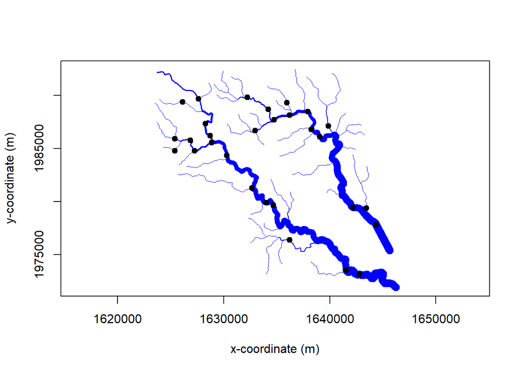

```r
plot(ssn_main, lwdLineCol = "afvArea", lwdLineEx = 10, lineCol = "blue",
pch = 19, xlab = "x-coordinate (m)", ylab = "y-coordinate (m)",
asp = 1)
```

save the plot to directory

```r
#save plot to directory
jpeg("data/ICPRB6/plots/afvArea.jpg")
plot(ssn_main, lwdLineCol = "afvArea", lwdLineEx = 10, lineCol = "blue",
pch = 19, xlab = "x-coordinate (m)", ylab = "y-coordinate (m)",
asp = 1)
```

“Our example response variable, Summer_mn, is the average summer stream temperature. This response is plotted across the stream network with observation locations colored by their value (Figure 4):” In our case we used TWAT in place of Summer_nm

and then plot “The generic plotting function of the SpatialStreamNetwork object” to r markdown

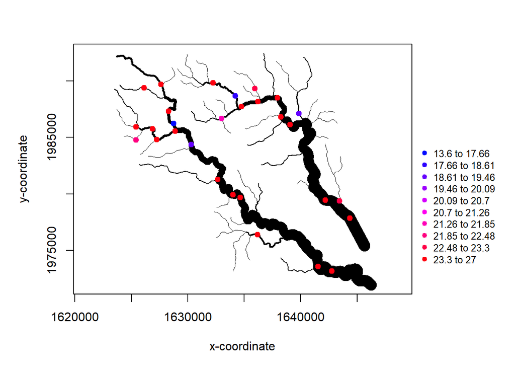

```r
plot(ssn_main, "TWAT", lwdLineCol = "afvArea",
lwdLineEx = 15, lineCol = "black", xlab = "x-coordinate" ,
ylab = "y-coordinate", asp=1 )
```

save to diretory

```r
#save plot to directory
jpeg("data/ICPRB6/plots/brks.jpg")
brks <- plot(ssn_main, "TWAT", lwdLineCol = "afvArea",
lwdLineEx = 15, lineCol = "black", xlab = "x-coordinate" ,
ylab = "y-coordinate", asp=1 )
```

“The observed values are represented by colored points and the stream network is shown in black, with the width of the lines proportional to the afvArea column.”

plot using sp classes to r markdown

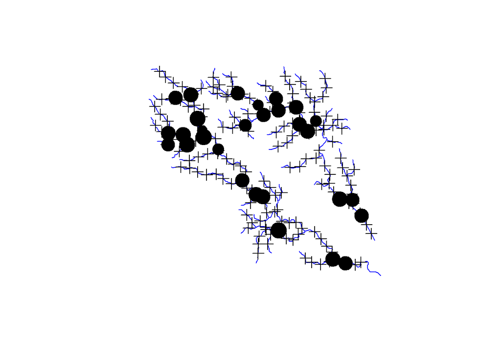

```r
#plot the stream lines
plot(as.SpatialLines(ssn_main), col = "blue")
# add the observed locations with size proportional
# to mean summer temperature
plot(as.SpatialPoints(ssn_main), pch = 19,
cex = as.SpatialPointsDataFrame(ssn_main)$TWAT/9 , add = TRUE)
# add the prediction locations on the 1 km spacing
plot(as.SpatialPoints(ssn_main, data = "preds"), cex = 1.5, add = TRUE)
```

```r
# add the dense set of points for block prediction on Knapp segment
###I don't have an equivalent data set to add
# plot(as.SpatialPoints(ssn_main, data = "Knapp"), pch = 19, cex = 0.3,
# col = "red", add = TRUE)
```

and save to directory

```r
#save plot to directory
jpeg("data/ICPRB6/plots/spatial.jpg")
plot(as.SpatialLines(ssn_main), col = "blue")
plot(as.SpatialPoints(ssn_main), pch = 19,
cex = as.SpatialPointsDataFrame(ssn_main)$TWAT/9 , add = TRUE)
plot(as.SpatialPoints(ssn_main, data = "preds"), cex = 1.5, add = TRUE)
```

plot “Torgegram of the mean summer temperature” to markdown

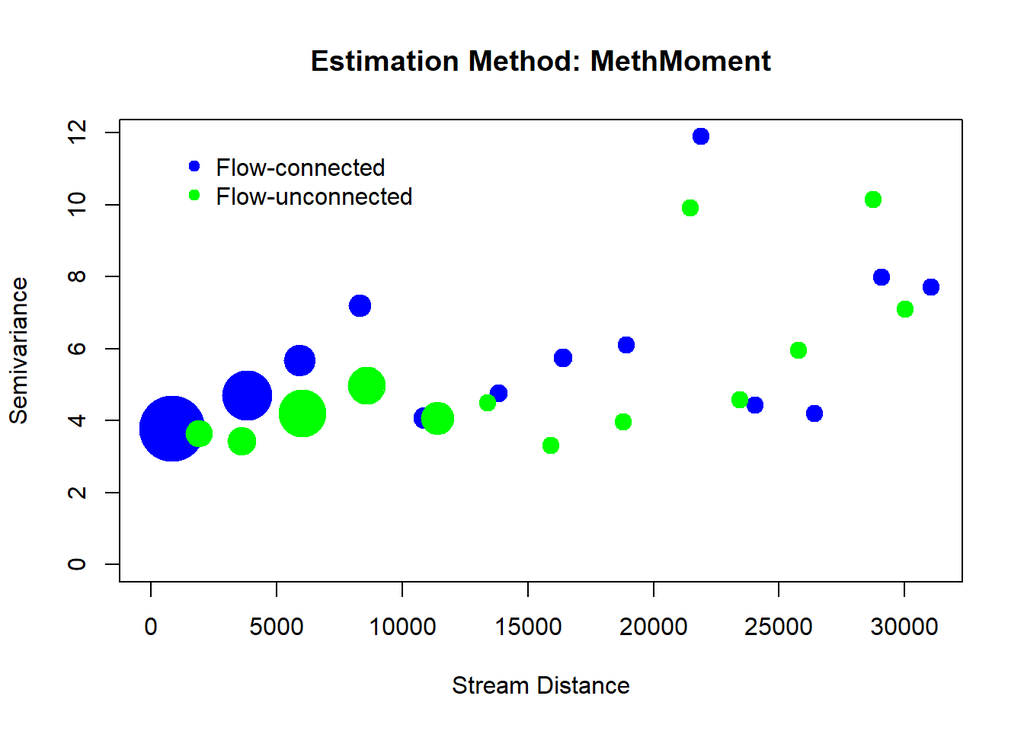

```r
ssn_main.Torg <- Torgegram(ssn_main, "TWAT", nlag = 20, maxlag = 50000)

plot(ssn_main.Torg)
```

save plot to directory

```r
#output graphic to directory
jpeg("data/ICPRB6/plots/torg.jpg")
plot(ssn_main.Torg)
```

# 5.2. Model fitting

```r
ssn_main.glmssn0 <- glmssn(TWAT ~ ELEV + SLOPE, ssn_main,
CorModels = NULL, use.nugget = TRUE)
summary(ssn_main)
```

```
## Object of class Spatial Stream Network
##
## Object includes observations on 45 variables across 2798 sites within the bounding box
##       min     max
## x 1623493 1646235
## y 1971928 1992448
##
## Object also includes 1 set of prediction points with 43176 locations
##
## Variables recorded are (found using names(object)):
## $Obs
##  [1] "SITEID"     "LONG_"      "LAT"        "DATE_"      "YEAR_"
##  [6] "MONTH_"     "GNIS_NAME"  "HUC12"      "GAGE"       "WEATHER"
## [11] "COMID"      "TWAT"       "TAIR"       "PRECIP"     "SOLRAD"
## [16] "ELEV"       "SLOPE"      "PURB16"     "PFOR16"     "PAG16"
## [21] "PWSTOR16"   "PCAN14"     "PIMP14"     "PEWET"      "PFWET"
## [26] "PRWET"      "PHYDA"      "AREAKM2"    "TOTDAKM2"   "SSO"
## [31] "BFI"        "WSHED"      "Note_"      "NEAR_FID"   "NEAR_DIST"
## [36] "NEAR_X"     "NEAR_Y"     "NEAR_ANGLE" "rid"        "ratio"
## [41] "upDist"     "afvArea"    "locID"      "netID"      "pid"
##
## $preds
##  [1] "SITEID"     "LONG_"      "LAT"        "DATE_"      "YEAR_"
##  [6] "MONTH_"     "GNIS_NAME"  "HUC12"      "GAGE"       "WEATHER"
## [11] "COMID"      "TWAT"       "TAIR"       "PRECIP"     "SOLRAD"
## [16] "ELEV"       "SLOPE"      "PURB16"     "PFOR16"     "PAG16"
## [21] "PWSTOR16"   "PCAN14"     "PIMP14"     "PEWET"      "PFWET"
## [26] "PRWET"      "PHYDA"      "AREAKM2"    "TOTDAKM2"   "SSO"
## [31] "BFI"        "WSHED"      "Note_"      "NEAR_FID"   "NEAR_DIST"
## [36] "NEAR_X"     "NEAR_Y"     "NEAR_ANGLE" "rid"        "ratio"
## [41] "upDist"     "afvArea"    "locID"      "netID"      "pid"
##
## Generic functions that work with this object include names, plot, print, summary, hist, boxplot and qqnorm
```

summary for comparison

```r
#comparison
summary(lm(TWAT ~ ELEV + SLOPE, getSSNdata.frame(ssn_main)))
```

```
##
## Call:
## lm(formula = TWAT ~ ELEV + SLOPE, data = getSSNdata.frame(ssn_main))
##
## Residuals:
##     Min      1Q  Median      3Q     Max
## -7.1358 -1.4686  0.1513  1.5480  6.8406
##
## Coefficients:
##               Estimate Std. Error t value Pr(>|t|)
## (Intercept)  20.884471   0.159627 130.833  < 2e-16 ***
## ELEV          0.004287   0.001172   3.658 0.000259 ***
## SLOPE       -98.699049   8.461926 -11.664  < 2e-16 ***
## ---
## Signif. codes:  0 '***' 0.001 '**' 0.01 '*' 0.05 '.' 0.1 ' ' 1
##
## Residual standard error: 2.116 on 2795 degrees of freedom
## Multiple R-squared:  0.0477, Adjusted R-squared:  0.04702
## F-statistic:    70 on 2 and 2795 DF,  p-value: < 2.2e-16
```

“A spatial model, including a mixture of tail-up, tail-down, and Euclidean covariance models is fitted:”

```r
ssn_main.glmssn1 <- glmssn(TWAT ~ ELEV + SLOPE, ssn_main,
CorModels = c("Exponential.tailup", "Exponential.taildown",
"Exponential.Euclid"), addfunccol = "afvArea")
summary(ssn_main.glmssn1)
```

```
##
## Call:
## glmssn(formula = TWAT ~ ELEV + SLOPE, ssn.object = ssn_main,
##     CorModels = c("Exponential.tailup", "Exponential.taildown",
##         "Exponential.Euclid"), addfunccol = "afvArea")
##
## Residuals:
##     Min      1Q  Median      3Q     Max
## -8.1197 -2.1163 -0.4315  0.9671  5.7877
##
## Coefficients:
##               Estimate Std. Error t value Pr(>|t|)
## (Intercept)  22.426709   2.459195   9.120   <2e-16 ***
## ELEV         -0.006695   0.014598  -0.459    0.647
## SLOPE       -50.709686  61.928737  -0.819    0.413
## ---
## Signif. codes:  0 '***' 0.001 '**' 0.01 '*' 0.05 '.' 0.1 ' ' 1
##
## Covariance Parameters:
##      Covariance.Model Parameter  Estimate
##    Exponential.tailup   parsill     0.970
##    Exponential.tailup     range  6166.732
##  Exponential.taildown   parsill     0.304
##  Exponential.taildown     range   451.444
##    Exponential.Euclid   parsill     5.498
##    Exponential.Euclid     range 92787.226
##                Nugget   parsill     3.193
##
## Residual standard error: 3.156862
## Generalized R-squared: 0.0003787075
```

needs attention: we don’t have a MaxOver20 covariate/variable/? set boundary for max limit of temp can write as a script that runs if a value false in this range. Have one for each likely range.

```r
# ssn_main.glmssnBin <- glmssn(MaxOver20 ~ ELEV + SLOPE, ssn_main,
# CorModels = c("Mariah.tailup", "Spherical.taildown"),
# family = "binomial", addfunccol = "afvArea")
# summary(ssn_main.glmssnBin)
```

needs attention: no C16 or equivalent set boundary for max limit of temp

```r
# ssn_main.glmssnPoi <- glmssn(C16 ~ ELEV + SLOPE, ssn_main,
# CorModels = c("LinearSill.tailup", "LinearSill.taildown"),
# family = "poisson", addfunccol = "afvArea")
# summary(ssn_main.glmssnPoi)
```

# 5.3. Residuals and diagnostics

get residiuals

```r
ssn_main.resid1 <- residuals(ssn_main.glmssn1)
names( getSSNdata.frame(ssn_main.resid1) )
```

```
##  [1] "pid"             "SITEID"          "LONG_"           "LAT"
##  [5] "DATE_"           "YEAR_"           "MONTH_"          "GNIS_NAME"
##  [9] "HUC12"           "GAGE"            "WEATHER"         "COMID"
## [13] "TWAT"            "TAIR"            "PRECIP"          "SOLRAD"
## [17] "ELEV"            "SLOPE"           "PURB16"          "PFOR16"
## [21] "PAG16"           "PWSTOR16"        "PCAN14"          "PIMP14"
## [25] "PEWET"           "PFWET"           "PRWET"           "PHYDA"
## [29] "AREAKM2"         "TOTDAKM2"        "SSO"             "BFI"
## [33] "WSHED"           "Note_"           "NEAR_FID"        "NEAR_DIST"
## [37] "NEAR_X"          "NEAR_Y"          "NEAR_ANGLE"      "rid"
## [41] "ratio"           "upDist"          "afvArea"         "locID"
## [45] "netID"           "obsval"          "_fit_"           "_resid_"
## [49] "_resid.stand_"   "_resid.student_" "_leverage_"      "_CooksD_"
```

save plot to directory

```r
#output graphic to directory
jpeg("data/ICPRB6/plots/resid_plot.jpg")
plot(ssn_main.resid1)
```

and plot to r markdown

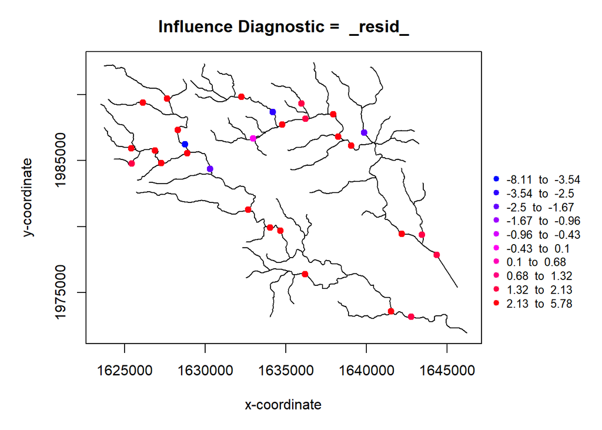

```r
plot(ssn_main.resid1)
```

save plot to directory

```r
#output graphic to directory
jpeg("data/ICPRB6/plots/resid_hist.jpg")
par(mfrow = c(1, 2))
hist(ssn_main.resid1)
hist(ssn_main, "TWAT")
```

plot to markdown

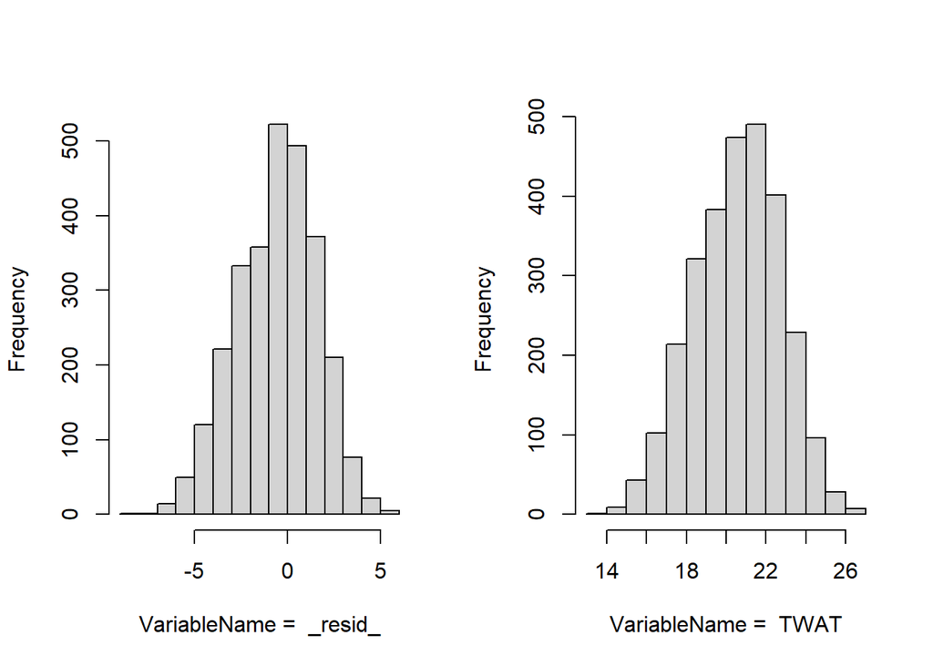

```r
par(mfrow = c(1, 2))
hist(ssn_main.resid1)
hist(ssn_main, "TWAT")
```

```r
ObsDFr <- getSSNdata.frame(ssn_main.resid1)
ObsDF <- getSSNdata.frame(ssn_main)
indOutlier <- ObsDFr["_resid_"] < -3
ObsDF[indOutlier, "TWAT"] <- NA
ssn_mainc <- putSSNdata.frame(ObsDF, ssn_main)
```

```r
ssn_mainc.glmssn0 <- glmssn(TWAT ~ ELEV + SLOPE, ssn_mainc,
CorModels = c("Exponential.tailup", "Exponential.taildown",
"Exponential.Euclid"), addfunccol = "afvArea", EstMeth = "ML")
summary(ssn_mainc.glmssn0)
```

```
##
## Call:
## glmssn(formula = TWAT ~ ELEV + SLOPE, ssn.object = ssn_mainc,
##     CorModels = c("Exponential.tailup", "Exponential.taildown",
##         "Exponential.Euclid"), addfunccol = "afvArea", EstMeth = "ML")
##
## Residuals:
##     Min      1Q  Median      3Q     Max
##      NA -1.0224  0.1511  1.5391      NA
##
## Coefficients:
##               Estimate Std. Error t value Pr(>|t|)
## (Intercept)  23.805212   0.914758  26.024  < 2e-16 ***
## ELEV         -0.019369   0.007093  -2.731  0.00637 **
## SLOPE       -50.246424  22.115499  -2.272  0.02318 *
## ---
## Signif. codes:  0 '***' 0.001 '**' 0.01 '*' 0.05 '.' 0.1 ' ' 1
##
## Covariance Parameters:
##      Covariance.Model Parameter   Estimate
##    Exponential.tailup   parsill     0.0230
##    Exponential.tailup     range   734.0691
##  Exponential.taildown   parsill     1.1772
##  Exponential.taildown     range 47024.0542
##    Exponential.Euclid   parsill     0.0190
##    Exponential.Euclid     range 93034.2820
##                Nugget   parsill     2.2287
##
## Residual standard error: 1.856836
## Generalized R-squared: 0.007268858
```

```r
summary(lm(TWAT ~ ELEV + SLOPE, getSSNdata.frame(ssn_main)))
```

```
##
## Call:
## lm(formula = TWAT ~ ELEV + SLOPE, data = getSSNdata.frame(ssn_main))
##
## Residuals:
##     Min      1Q  Median      3Q     Max
## -7.1358 -1.4686  0.1513  1.5480  6.8406
##
## Coefficients:
##               Estimate Std. Error t value Pr(>|t|)
## (Intercept)  20.884471   0.159627 130.833  < 2e-16 ***
## ELEV          0.004287   0.001172   3.658 0.000259 ***
## SLOPE       -98.699049   8.461926 -11.664  < 2e-16 ***
## ---
## Signif. codes:  0 '***' 0.001 '**' 0.01 '*' 0.05 '.' 0.1 ' ' 1
##
## Residual standard error: 2.116 on 2795 degrees of freedom
## Multiple R-squared:  0.0477, Adjusted R-squared:  0.04702
## F-statistic:    70 on 2 and 2795 DF,  p-value: < 2.2e-16
```

```r
ssn_mainc.glmssn1 <- glmssn(TWAT ~ ELEV + SLOPE, ssn_mainc,
CorModels = c("Exponential.tailup", "Exponential.taildown"),
addfunccol = "afvArea", EstMeth = "ML")
summary(ssn_mainc.glmssn1)
```

```
##
## Call:
## glmssn(formula = TWAT ~ ELEV + SLOPE, ssn.object = ssn_mainc,
##     CorModels = c("Exponential.tailup", "Exponential.taildown"),
##     addfunccol = "afvArea", EstMeth = "ML")
##
## Residuals:
##     Min      1Q  Median      3Q     Max
##      NA -0.9912  0.1834  1.5743      NA
##
## Coefficients:
##              Estimate Std. Error t value Pr(>|t|)
## (Intercept)  23.81721    0.92166  25.842  < 2e-16 ***
## ELEV         -0.01978    0.00712  -2.778  0.00551 **
## SLOPE       -49.16487   20.91594  -2.351  0.01882 *
## ---
## Signif. codes:  0 '***' 0.001 '**' 0.01 '*' 0.05 '.' 0.1 ' ' 1
##
## Covariance Parameters:
##      Covariance.Model Parameter    Estimate
##    Exponential.tailup   parsill     0.00364
##    Exponential.tailup     range  2250.53030
##  Exponential.taildown   parsill     1.24955
##  Exponential.taildown     range 47711.54591
##                Nugget   parsill     2.22833
##
## Residual standard error: 1.865886
## Generalized R-squared: 0.007630612
```

need to save plots to directory

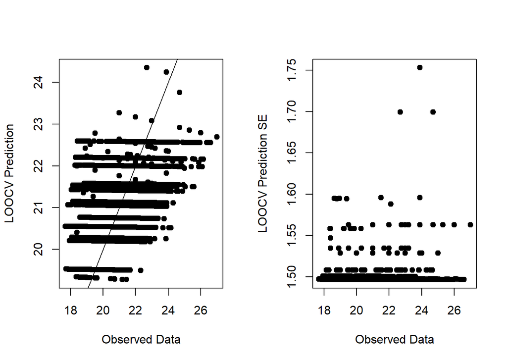

```r
cv.out <- CrossValidationSSN(ssn_mainc.glmssn1)
par(mfrow = c(1, 2))
plot(ssn_mainc.glmssn1$sampinfo$z,
cv.out[, "cv.pred"], pch = 19,
xlab = "Observed Data", ylab = "LOOCV Prediction")
abline(0, 1)
plot( na.omit( getSSNdata.frame(ssn_mainc)[, "TWAT"]),
cv.out[, "cv.se"], pch = 19,
xlab = "Observed Data", ylab = "LOOCV Prediction SE")
```

save plot to directory

```r
jpeg("data/ICPRB6/plots/crossvalidation.jpg")
par(mfrow = c(1, 2))
plot(ssn_mainc.glmssn1$sampinfo$z,
cv.out[, "cv.pred"], pch = 19,
xlab = "Observed Data", ylab = "LOOCV Prediction")
abline(0, 1)
plot(na.omit( getSSNdata.frame(ssn_mainc)[, "TWAT"]),
cv.out[, "cv.se"], pch = 19,
xlab = "Observed Data", ylab = "LOOCV Prediction SE")
```

```r
CrossValidationStatsSSN(ssn_mainc.glmssn1)
```

| bias | std.bias | RMSPE | RAV | std.MSPE | cov.80 | cov.90 | cov.95 |
| --- | --- | --- | --- | --- | --- | --- | --- |
| 0.0002974802 | 0.0001793531 | 1.500491 | 1.49908 | 1.001028 | 0.7934783 | 0.9034281 | 0.958194 |

```r
GR2(ssn_mainc.glmssn1)
```

```
##             [,1]
## [1,] 0.007630612
```

```r
varcomp(ssn_mainc.glmssn1)
```

| VarComp | Proportion |
| --- | --- |
| Covariates (R-sq) | 0.007630612 |
| Exponential.tailup | 0.001038785 |
| Exponential.taildown | 0.356170176 |
| Nugget | 0.635160426 |

# 5.4. Model selection

```r
AIC(ssn_mainc.glmssn0)
```

```
## [1] 8783.679
```

```r
AIC(ssn_mainc.glmssn1)
```

```
## [1] 8779.368
```

WARNING: This next section of code will take several days to run

```r
ssn_mainc.glmssn1 <- glmssn(TWAT ~ ELEV, ssn_mainc,
CorModels = c("Exponential.tailup", "Exponential.taildown"),
addfunccol = "afvArea", EstMeth = "ML")

######below glmssn can be run when we know the first one runs############

# ssn_mainc.glmssn2 <- glmssn(TWAT ~ ELEV, ssn_mainc,
# CorModels = c("LinearSill.tailup", "Mariah.taildown"),
# addfunccol = "afvArea")
#
# ssn_mainc.glmssn3 <- glmssn(TWAT ~ ELEV, ssn_mainc,
# CorModels = c("Mariah.tailup", "LinearSill.taildown"),
# addfunccol = "afvArea")
#
# ssn_mainc.glmssn4 <- glmssn(TWAT ~ ELEV, ssn_mainc,
# CorModels = c("Spherical.tailup", "Spherical.taildown"),
# addfunccol = "afvArea")
#
# ssn_mainc.glmssn5 <- glmssn(TWAT ~ ELEV, ssn_mainc,
# CorModels = "Exponential.Euclid",
# addfunccol = "afvArea")
```

compare glmssn objects (can’t run without running all glmssn above) For the pruposes of folowing the vignete script we will assume that ssn_mainc.glmssn1 model is the best fit for our data.

```r
# options(digits = 4)
# InfoCritCompare(list(ssn_mainc.glmssn1, ssn_mainc.glmssn2,
# ssn_mainc.glmssn3, ssn_mainc.glmssn4, ssn_mainc.glmssn5))
#
# options(digits = 7)
```

at this point the glmssn model that best fits the data should be used. For now we will use glmssn1

summary of ssn_mainc.glmssin1

```r
summary(ssn_mainc.glmssn1) #was ssn_mainc.glmssn2
```

```
##
## Call:
## glmssn(formula = TWAT ~ ELEV, ssn.object = ssn_mainc, CorModels = c("Exponential.tailup",
##     "Exponential.taildown"), addfunccol = "afvArea", EstMeth = "ML")
##
## Residuals:
##     Min      1Q  Median      3Q     Max
##      NA -0.9618  0.2479  1.6921      NA
##
## Coefficients:
##             Estimate Std. Error t value Pr(>|t|)
## (Intercept) 23.62162    0.90403  26.129  < 2e-16 ***
## ELEV        -0.02235    0.00693  -3.225  0.00128 **
## ---
## Signif. codes:  0 '***' 0.001 '**' 0.01 '*' 0.05 '.' 0.1 ' ' 1
##
## Covariance Parameters:
##      Covariance.Model Parameter   Estimate
##    Exponential.tailup   parsill     0.0777
##    Exponential.tailup     range  4668.1245
##  Exponential.taildown   parsill     1.1372
##  Exponential.taildown     range 44586.3226
##                Nugget   parsill     2.2198
##
## Residual standard error: 1.853306
## Generalized R-squared: 0.004310475
```

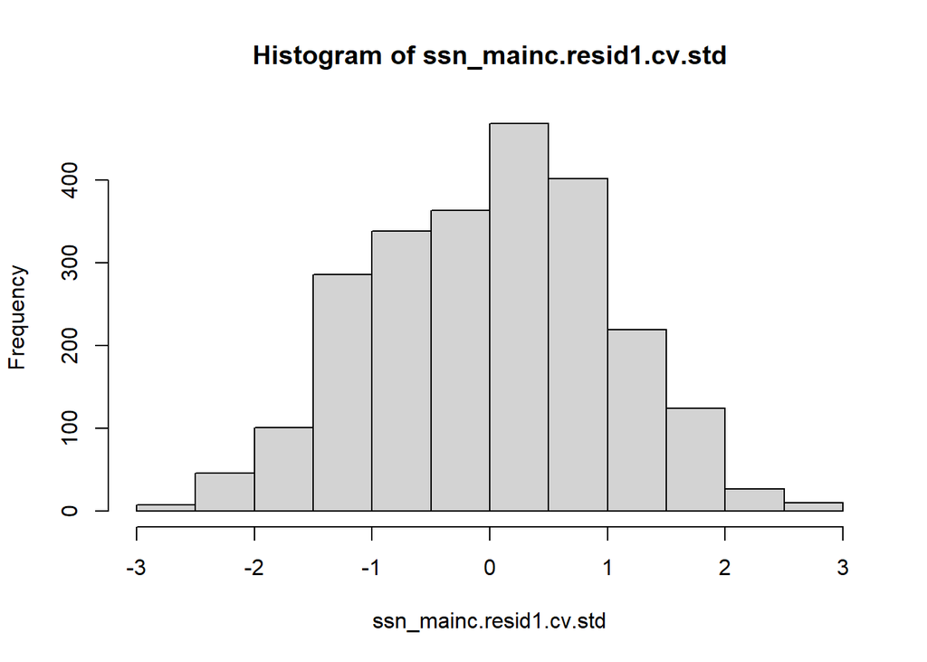

```r
ssn_mainc.resid1 <- residuals(ssn_mainc.glmssn1,
cross.validation = TRUE)
ssn_mainc.resid1.cv.std <-
getSSNdata.frame(ssn_mainc.resid1)[, "_resid.crossv_"] /
getSSNdata.frame(ssn_mainc.resid1)[, "_CrossValStdErr_"]
hist(ssn_mainc.resid1.cv.std)
```

save plot to directory

```r
jpeg("data/ICPRB6/plots/resid1_hist.jpg")
hist(ssn_mainc.resid1.cv.std)
```

plot torgegram

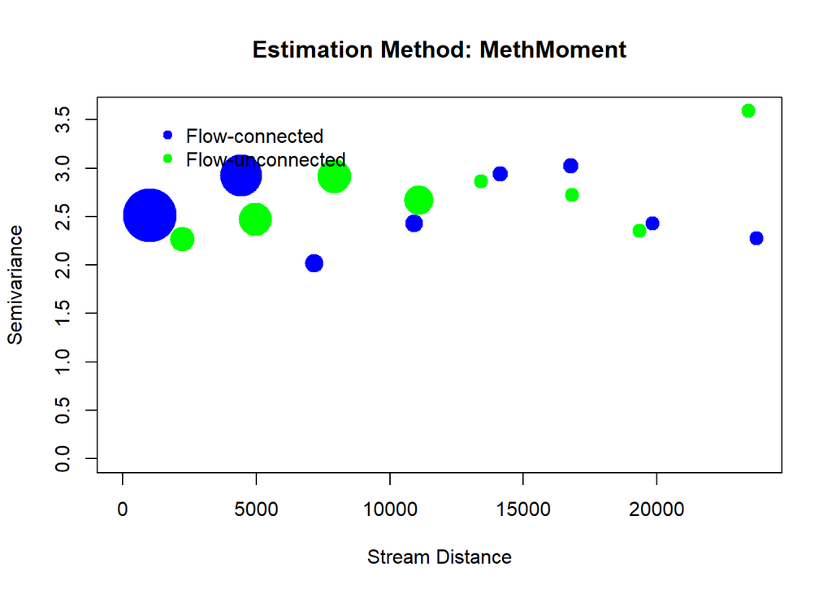

```r
plot(Torgegram(ssn_mainc.resid1, "_resid_", nlag = 8, maxlag = 25000))
```

save plot to directory

```r
jpeg("data/ICPRB6/plots/resid1_torg.jpg")
plot(Torgegram(ssn_mainc.resid1, "_resid_", nlag = 8, maxlag = 25000))
```

# 5.5 Predictions:

plot predictions

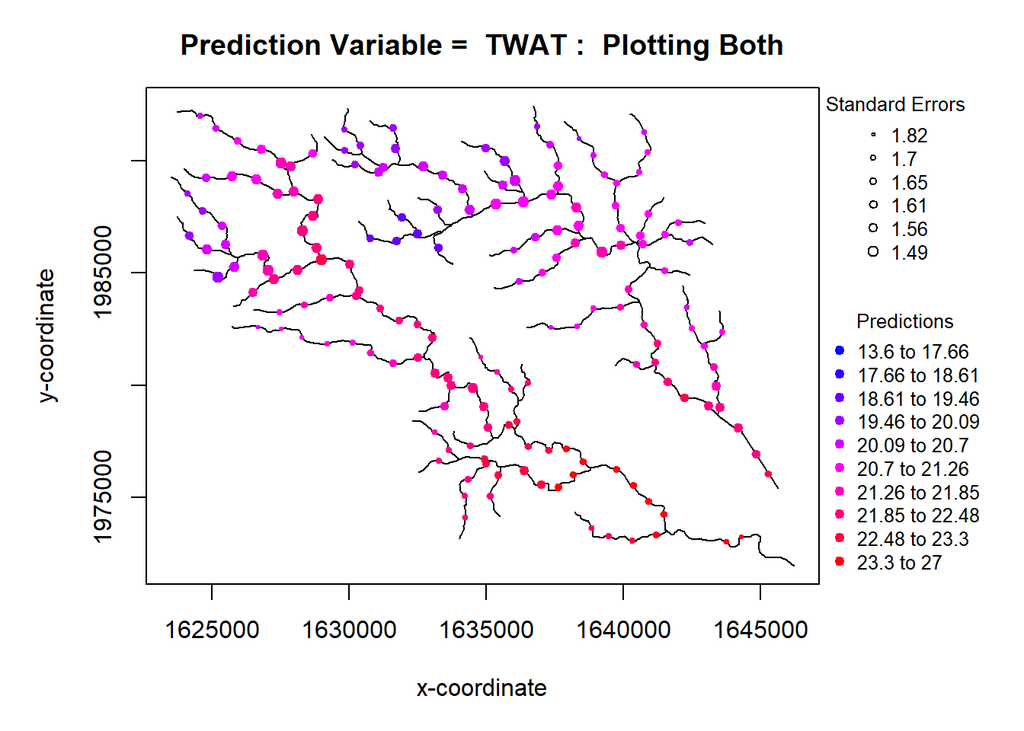

```r
ssn_mainc.preds <- predict(ssn_mainc.glmssn1, "preds") ##was ssn_mainc.glmssn4
plot(ssn_mainc.preds, SEcex.max = 1, SEcex.min = .5/3*2,
breaktype = "user", brks = brks)
```

save plot to directory

```r
jpeg("data/ICPRB6/plots/predictions.jpg")
plot(ssn_mainc.preds, SEcex.max = 1, SEcex.min = .5/3*2,
breaktype = "user", brks = brks)
```

Save ssn objects as dataframe csv outputs

```r
main_glmssn1.df <- getSSNdata.frame(ssn_main.glmssn1)
write.csv(main_glmssn1.df,"data/ICPRB6/dataframes/main_glmssn1.csv")

mainc_glmssn0.df <- getSSNdata.frame(ssn_mainc.glmssn0)
write.csv(mainc_glmssn0.df,"data/ICPRB6/dataframes/mainc_glmssn0.csv")

mainc_glmssn1.df <- getSSNdata.frame(ssn_mainc.glmssn1)
write.csv(mainc_glmssn1.df,"data/ICPRB6/dataframes/mainc_glmssn1.csv")

main_resid1.df <- getSSNdata.frame(ssn_main.resid1)
write.csv(main_resid1.df,"data/ICPRB6/dataframes/main_resid1.csv")

mainc_resid1.df <- getSSNdata.frame(ssn_mainc.resid1)
write.csv(mainc_resid1.df,"data/ICPRB6/dataframes/mainc_resid1.csv")

preds.df <- getSSNdata.frame(ssn_mainc.preds)
write.csv(preds.df,"data/ICPRB6/dataframes/preds.csv")
```

Here we would plot for other pred points, if available:

plot

```r
# plot(ssn_mainc, "TWAT", pch = 1, cex = 3,
# xlab = "x-coordinate", ylab = "y-coordinate",
# xlim = c(-1511000,-1500000), ylim = c(2525000,2535000))
# ssn_mainc.glmssn1.preds <- predict(ssn_mainc.glmssn1, "preds")
# plot(ssn_mainc.glmssn1.preds, "TWAT", add = TRUE,
# xlim = c(-1511000,-1500000), ylim = c(2525000,2535000))
```

save plot to directory

```r
# jpeg("data/ICPRB6/plots/.jpg")
# plot(ssn_mainc, "TWAT", pch = 1, cex = 3,
# xlab = "x-coordinate", ylab = "y-coordinate",
# xlim = c(-1511000,-1500000), ylim = c(2525000,2535000))
# ssn_mainc.glmssn1.preds <- predict(ssn_mainc.glmssn1, "preds")
# plot(ssn_mainc.glmssn1.preds, "TWAT", add = TRUE,
# xlim = c(-1511000,-1500000), ylim = c(2525000,2535000))
```

“By using matching break points for observed data and predicted data, we can see that predictions seem reasonable given the observed data. The prediction sites are on a dense evenly-spaced grid because they are used to approximate the integrals involved with block prediction:”

This won’t run. Produces “Error: cannot allocate vector of size 13.9 Gb”

```r
# ssn_mainc.glmssn1.BPPreds <- BlockPredict(ssn_mainc.glmssn1, "preds")
# ssn_mainc.glmssn1.BPPreds
```

“We can repeat this for another set of spatially dense locations on the Cape Horn tributary of the Middle Fork river:” We could run something like this if we had multiple pred regions/files:

```r
# mf04c.glmssn4.BPCapeHorn <- BlockPredict(mf04c.glmssn4, "CapeHorn")
# mf04c.glmssn4.BPCapeHorn
```

```r
# ssn_mainc.missingobs <- predict(ssn_mainc.glmssn1, "_MissingObs_")
# getPreds(ssn_mainc.missingobs, pred.type = "pred")
#
# with(getSSNdata.frame(ssn_main), TWAT[pid==29])
```

# 6. Simulating stream network data

# 6.1. Creating a SpatialStreamNetwork object

The following section appears to cover creating a SSN object in the abstract sense, as we have already done. I won’t be running any of the code below for this run, since none of it seems to apply specificaly to getting outputs from our dataset. You may want to read through this section in the vignette to verify if my assumption is correct.

```r
# createSSN(n, obsDesign, predDesign = noPoints, path,
# importToR = FALSE, treeFunction = igraphKamadaKawai)
```

need to save plot to directory

```r
# set.seed(12)
# iterative.ssn <- createSSN(n = c(30, 10),
# obsDesign = binomialDesign(c(10,10)),
# importToR = TRUE, path = "./SimIterative.ssn",
# treeFunction = iterativeTreeLayout)
# plot(iterative.ssn, lwdLineCol = "addfunccol", lwdLineEx = 8,
#      lineCol = "blue", cex = 2, xlab = "x-coordinate",
# ylab = "y-coordinate", pch = 1)
```

next two chunks are for one plot need to save plot to directory

```r
# set.seed(101)
# raw.ssn <- createSSN(n = c(10, 10, 10),
# obsDesign = binomialDesign(c(40, 40, 40)),
# predDesign = systematicDesign(c(0.2, 0.4, 0.8)), importToR = TRUE,
# path = "./raw.ssn")
# plot(raw.ssn, lwdLineCol = "addfunccol", lwdLineEx = 8,
# lineCol = "blue", cex = 2, xlab = "x-coordinate",
# ylab = "y-coordinate", pch = 1)
# plot(raw.ssn, PredPointsID = "preds", add = TRUE, cex = .5, pch = 19,
# col = "green")
```

```r
# set.seed(13)
# hardcore.ssn <- createSSN(n = c(10, 10),
# obsDesign = hardCoreDesign(c(200, 200), c(0.2, 0.4)),
# importToR = TRUE, path = "./SimHardcore.ssn")
# plot(hardcore.ssn, lwdLineCol = "addfunccol", lwdLineEx = 8,
# lineCol = "blue", cex = 2, xlab = "x-coordinate",
# ylab = "y-coordinate", pch = 1)
# plot(hardcore.ssn, PredPointsID = NULL, add = TRUE, cex = .5,
# pch = 19, col = "green")
```

# 6.2. Simulating data on the SpatialStreamNetwork object

```r
# createDistMat(raw.ssn, "preds", o.write=TRUE, amongpred = TRUE)
```

```r
# rawDFobs <- getSSNdata.frame(raw.ssn, "Obs")
# rawDFpred <- getSSNdata.frame(raw.ssn, "preds")
```

```r
# rawDFobs[,"X1"] <- rnorm(length(rawDFobs[,1]))
# rawDFpred[,"X1"] <- rnorm(length(rawDFpred[,1]))
# rawDFobs[,"X2"] <- rnorm(length(rawDFobs[,1]))
# rawDFpred[,"X2"] <- rnorm(length(rawDFpred[,1]))
```

```r
# rawDFobs[,"F1"] <- as.factor(sample.int(4,length(rawDFobs[,1]),
# replace = TRUE))
# rawDFpred[,"F1"] <- as.factor(sample.int(4,length(rawDFpred[,1]),
# replace = TRUE))
```

```r
# rawDFobs[,"RE1"] <- as.factor(sample(1:3,length(rawDFobs[,1]),
# replace = TRUE))
# rawDFobs[,"RE2"] <- as.factor(sample(1:4,length(rawDFobs[,1]),
# replace = TRUE))
# rawDFpred[,"RE1"] <- as.factor(sample(1:3,length(rawDFpred[,1]),
# replace = TRUE))
# rawDFpred[,"RE2"] <- as.factor(sample(1:4,length(rawDFpred[,1]),
# replace = TRUE))
```

```r
# set.seed(102)
# sim.out <- SimulateOnSSN(raw.ssn, ObsSimDF = rawDFobs,
# PredSimDF = rawDFpred, PredID = "preds",
# formula = ~ X1 + X2 + F1, coefficients = c(10,1,0,-2,0,2),
# CorModels = c("LinearSill.tailup", "Mariah.taildown",
# "Exponential.Euclid", "RE1", "RE2"), use.nugget = TRUE,
# CorParms = c(3, 10, 2, 10, 1, 5, 1, .5, .1),
# addfunccol = "addfunccol")
```

```r
# with(rawDFobs, colnames(model.matrix( ~ X1 + X2 + F1)))
```

```r
# sim.out$FixedEffects
#
# sim.out$CorParms
```

```r
# sim.ssn <- sim.out$ssn.object
```

plot needs to be saved to directory

```r
# plot(sim.ssn, "Sim_Values",
# xlab = "x-coordinate", ylab = "y-coordinate",
# cex = 1.5)
```

```r
# simDFobs <- getSSNdata.frame(sim.ssn, "Obs")
# simDFpred <- getSSNdata.frame(sim.ssn, "preds")
```

```r
# simpreds <- simDFpred[,"Sim_Values"]
# simDFpred[,"Sim_Values"] <- NA
# sim.ssn <- putSSNdata.frame(simDFpred, sim.ssn, "preds")
```

```r
# glmssn.out <- glmssn(Sim_Values ~ X1 + X2 + F1, sim.ssn,
# CorModels = c("LinearSill.tailup", "Mariah.taildown",
# "Exponential.Euclid", "RE1", "RE2"),
# addfunccol = "addfunccol")
```

```r
# summary(glmssn.out)
```

```r
# glmssn.pred <- predict(glmssn.out,"preds")
# predDF <- getSSNdata.frame(glmssn.pred, "preds")
# plot(simpreds, predDF[,"Sim_Values"], xlab = "True",
# ylab = "Predicted", pch = 19)
```

# 7. Discussion and future development

—Section to be added after studying outputs further—